# Efforts in Estimating the Incubation Period of 2019-nCoV

Nianqiao Ju

2/14/2020

## Data Collection

We have collected detailed information about infections in China.

```r
rm(list = ls())
data <- read.table("../data-raw/Feb14 - In China.tsv", sep = "\t", header = TRUE)
# cases.in.china <- data[c(1:161, 208:449), ]
# use_data(cases.in.china, overwrite = TRUE)
```

We convert the dates to ‘days since 1-Dec-2019’ format. In order to estimate the incubation period, we only include records with known symptom onset date or period. We assume that ‘symptom onset date’ is missing completely at random. Currently, the `parse.infected’ function assumes Arrival > Symptom, which is violated by ~ 32 cases. The new data.exposure function does not assume infection happens before arrival from Wuhan.

```r
## convert the dates to days since 1-Dec-2019
data$Confirmed <- date.process(data$Confirmed)
data$Arrived <- date.process(data$Arrived)
data$Symptom <- date.process(data$Symptom)
data$Initial <- date.process(data$Initial)
data$Hospital <- date.process(data$Hospital)
data$Source <- data$Cluster <- data$Death <- data$Discharged <- data$Verified <- data$Note <- NULL ## for visualization
## Only consider cases with known symptom onset
data <- subset(data, !is.na(Symptom))
## parse data
case72 <- data[72,] ## manually parse hefei-72
data <- data[-72,]
# data <- parse.infected(data)
data <- parse.exposure(data)
case72$Infected_first <- date.process("15-Jan")
case72$Infected_last <- date.process("21-Jan")
data <- rbind(data, case72)
```

- Patients who left Wuhan before 23-Jan-2020 and showed symptoms after leaving Wuhan. We have an lower bound $L_i \leq T_i$ for these patients.
- Some secondary infections results from interacting with patients from Hubei province. Some of these interactions, for example reunion with schoolmates or visiting a shopping center, are observed to the precision of one day or a few days. We observe $L_i \leq T_i \leq U_i$.
- Most of the secondary infections were due to living with family members from outside and their infection date must be later than the arrival date of the family member. As a result, an upper bound can be imputed $0 < T_i \leq U_i.$ For those families that self-quarantined, we can impute also a lower bound $L_i < T_i < U_i$.

```r
## we may choose only to study patients that left Wuhan on or before January 23
# data <- subset(data, Arrived <= 23+31)
# data <- subset(data, Symptom - Infected_last <= 20) ## removing outliers
# data <- subset(data, Confirmed <= 28 + 31) ## cutoff by confirmation date
## remove cases with no information at all
data <- subset(data, !(Infected_first == 1 & Infected_last == Symptom))
print(dim(data))
```

```
## [1] 132  14
```

| type | count |
| --- | --- |
| upper bound only | 33 |
| lower bound only | 16 |
| lower and upper bound | 34 |
| knows the date of infection | 49 |
| total | 132 |

For these patients we only have an lower bound for $T$.

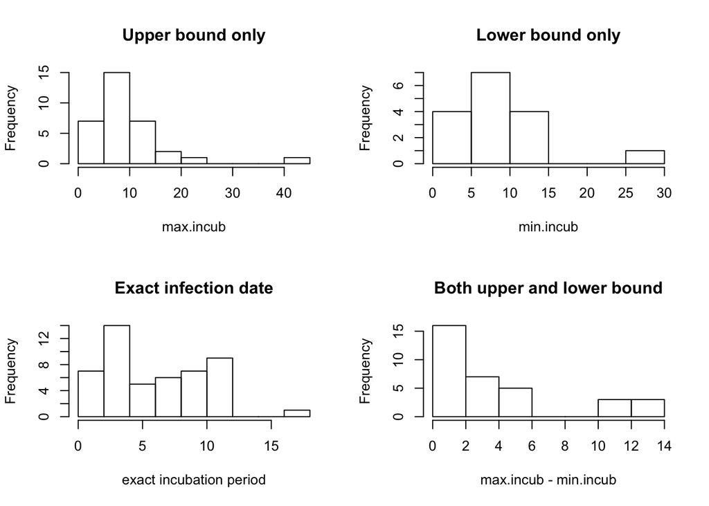

## Methods

We start with simple parametric models that does not incorporate covariates such as age and gender.

```r
# data <- data %>% mutate(min.incub = Symptom - Infected_last - 0.5, max.incub = Symptom - Infected_first + 0.5)
# attach(data)
# loglikelihood <- function(par, family = 'gamma'){
##### function under construction
#   ## reparametrization (mean, sd) -> shape, rate, scale etc.
#   if (family == 'gamma'){
#     b <- par[1] / par[2]**2
#     a <- par[1] * b
#     logweights <- log(pgamma(q = max.incub, shape = a, rate = b) - pgamma(q = min.incub, shape = a, rate = b))
#   }
#   if (family == 'lognormal'){
#     meanlog = 2 * log(par[1]) - 0.5 * log( par[1]**2 + par[2]**2)
#     sdlog = sqrt(log(par[2]**2 + par[1]**2) - 2 * log(par[1]))
#     logweights <- log(plnorm(q = max.incub, meanlog = meanlog, sdlog = sdlog) - plnorm(q = min.incub, meanlog = meanlog, sdlog = sdlog))
#   }
#   if (family == 'weibull'){
#     aa <- ((par[2]/par[1])**2  + 1) /2 ## kGamma(2/k) / Gamma(1/k)
#     logaa <- log(aa)
#     ## find k such that logk + loggamma(2/k) - loggamma(1/k) - a = 0
#     k <- uniroot(f = function(x) log(x) + lgamma(2/x) - lgamma(1/x) - logaa, interval = c(1,10))$root
#     ## check
#     if (abs(log(k) + lgamma(2/k) - lgamma(1/k) - logaa) > 1e-5) print('weibull numerical solver problem')
#     l <- gamma(1 + 1/k) / par[1]
#     logweights <- log(pweibull(q = max.incub, shape = k, scale = l) - pweibull(q = min.incub, shape = k, scale = l))
#     }
#   maxlogweights <- max(logweights)
#   logweights <- logweights - maxlogweights
#   loglik <- log(sum(exp(logweights))) + maxlogweights
#   loglik
# }

data <- data %>% mutate(min.incub = Symptom - Infected_last) %>% mutate(max.incub = Symptom - Infected_first)
loglikelihood <- function(par, family = 'gamma') {
    GT <- R0::generation.time(type = family, par, truncate = 100);
    loglike <- 0
    for (i in 1:nrow(data)) {
        if (data$max.incub[i] == 0){
            loglike <- loglike + log(GT$GT[2])
        }else{
            loglike <- loglike + log(sum(GT$GT[1 + (data$min.incub[i]):(data$max.incub[i])])) ## +1 for starting at zero
        }
        if (is.infinite(loglike)){
            print(i)
            print(data[i,])
            break
        }
    }
    loglike
}

par <- c(7.5, 3.5)
loglikelihood(par, family = 'lognormal')
```

```
## [1] -236.8155
```

```r
calculate_mle <- function(init = c(7.5, 3.5), family = 'gamma'){
  fit <- optim(par = init, fn = function(x) loglikelihood(x, family), control = list(fnscale = -1))
  fit
}
```

```r
parametric_families <- c('gamma','lognormal','weibull')
mle_table <- data.frame(distribution = parametric_families, mean = NA, sd = NA, loglikelihood = NA)
for (i in 1:length(parametric_families)){
  mle <- calculate_mle(family = parametric_families[i])
  mle_table[i, c(2,3)] <- as.numeric(mle$par)
  mle_table[i,4] <- as.numeric(mle$value)
}
print(mle_table)
```

```
##   distribution     mean       sd loglikelihood
## 1        gamma 6.729998 4.502690     -208.6277
## 2    lognormal 6.968922 5.523485     -209.3579
## 3      weibull 6.627077 4.500858     -209.5080
```

The three parametric models have similar loglikelihood. We can look at the 95% quantile for $T$ based on the gamma model.

```r
b <- mle_table[1,2] / mle_table[1,3] **2
a <- mle_table[1,2] * b
## 95% quantile for T
c(qgamma(p = 0.025, shape = a, rate = b),qgamma(p = 1 - 0.025, shape = a, rate = b))
```

```
## [1]  0.9614535 17.9915313
```

```r
## IQR
c(qgamma(p = 0.25, shape = a, rate = b),qgamma(p = 1 - 0.25, shape = a, rate = b))
```

```
## [1] 3.419770 8.991635
```

We can also look at the survival curve $P(T \geq t)$.

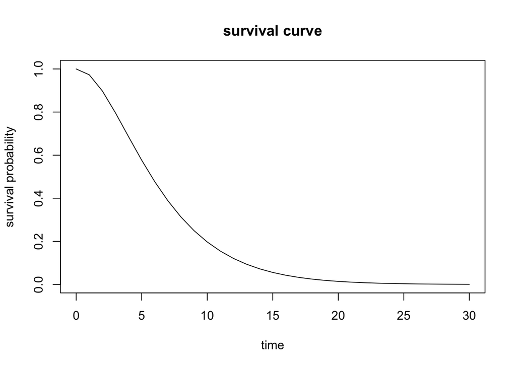

```r
t_v <- seq(0,30,1)
cmf <- pgamma(q = t_v, shape = a, rate = b)
plot(t_v, 1 - cmf,
     xlab = 'time', ylab = 'survival probability', main = 'survival curve',
     type = 'l')
```

I choose to display the credible region based on the gamma model here.

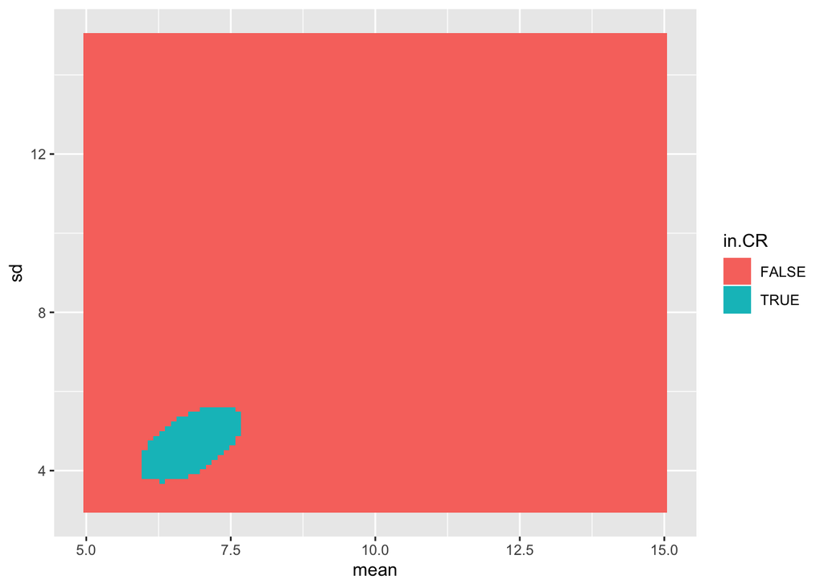

```r
pars <- expand.grid(mean = seq(5, 15, length.out = 100), sd = seq(3, 15, length.out = 100))
pars$loglike <- apply(pars, 1, FUN = function(par) loglikelihood(par))
# print(pars[which.max(pars$loglike),]) ## print the grid-search MLE to terminal
pars$in.CR <- (pars$loglike > mle_table[1,4] - qchisq(0.95, 1) / 2)
p2 <- ggplot(pars) + aes(x = mean, y = sd, fill = in.CR) +geom_tile()
p2
```

The incubation period estimate reported here is much higher than previous studies. This can partially be explained by the more up-to-date data that we collected. Earlier reports collected cases that are biased towards patients that display shorter incubation periods. We need to think through our subset selection criterion and examine if there is any bias. I also find some outliers in the data.

## Outliers

Some cases have very large lower bound for $T_i$.

```r
subset(data, Symptom - Infected_last > 20)
```

```
##          Case Nationality.Residence Gender Age Known.Contact Outside
## 131 anqing-80  chinese/anhui/anqing      M  20                     Y
##         Infected Arrived Symptom Initial Hospital Confirmed Infected_first
## 131 ? to 10-Jan       41      69      71       NA        72              1
##     Infected_last min.incub max.incub
## 131            41        28        68
```

## adding age as a covariate

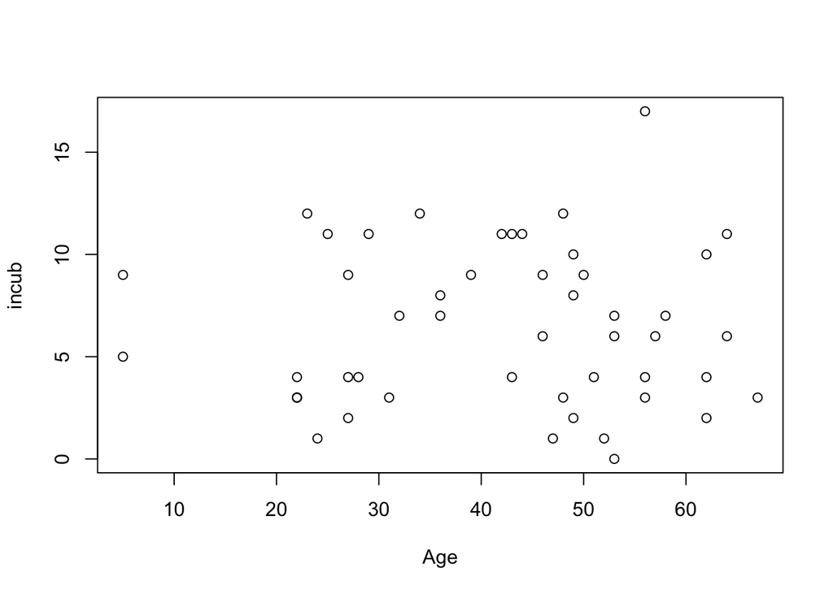

```r
plot(incub ~ Age, data = exact)
```

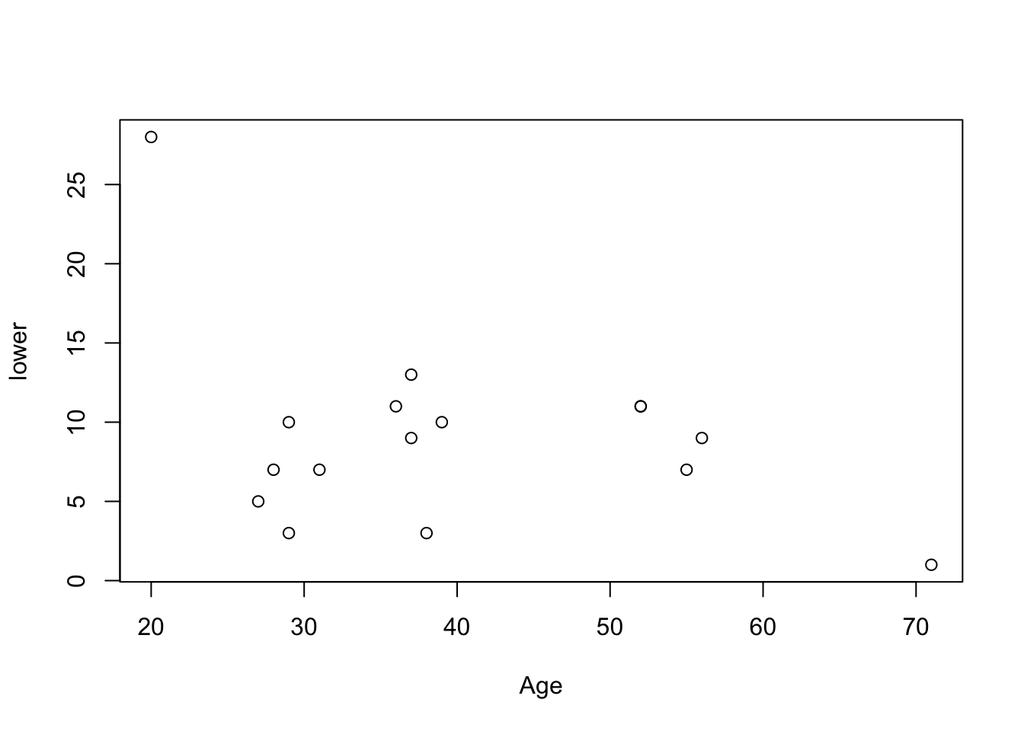

```r
plot(lower ~ Age, data = lower)
```

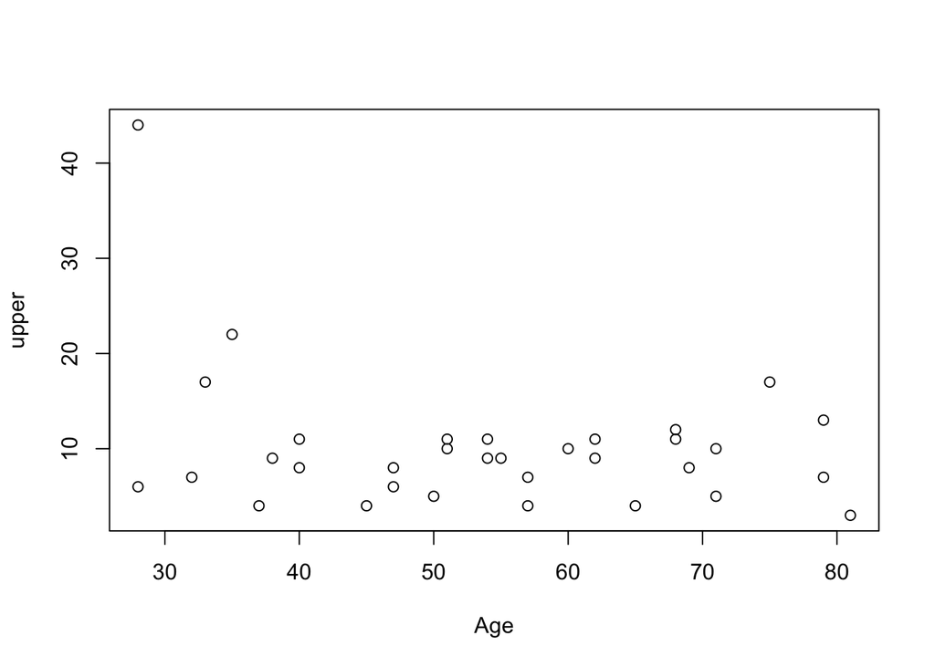

```r
plot(upper ~ Age, data = upper)
```

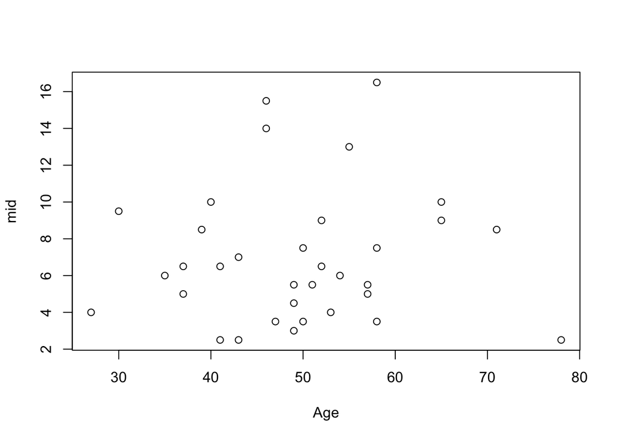

```r
band <- band %>% mutate(mid = Symptom - 0.5 * Infected_first - 0.5 * Infected_last)
plot(mid ~ Age, data = band)
```